# Manipulating data frames, part 2

Let’s move on to some linguistic data. This is data from sociolinguistic interviews conducted in Philadelphia - which was cleaned up and made available by [Joe Fruehwald](http://jofrhwld.github.io/). The data package we’ll be downloading also includes data of his own vowels, which you can play around with on your own! To download it, we first have to install some packages in R.

Once `devtools` is installed and opened, we can download the data.

```r
install.packages("devtools", repos = "http://cran.us.r-project.org")
library(devtools)
install_github("jofrhwld/grammarOfVariationData")
library(grammarOfVariationData)
```

To see what data frames come in this data set:

```r
data(package = "grammarOfVariationData")
```

This automatically opens up another tab in the editor window, which gives a list of the data sets in `grammarOfVariationData`. We’ll be looking at the `ing` data, which is a data set of ING vs. IN’ according to different styles and grammatical status. Asking R for the number of rows with `nrow()` shows us that `ing` contains 1139 observations – too many to look at at once. To get a sense of what the data looks like, we’ll check it out with `head()`. Here I’m adding the optional argument `, 5` to get the first 5 rows.

```r
nrow(ing)
```

```
## [1] 1139
```

```r
head(ing, 5)
```

```
##       Token DepVar   Style  GramStatus Following.Seg Sex Age Ethnicity
## 54    going     In careful progressive         vowel   f   2     Irish
## 55   giving     In careful progressive         vowel   f   2     Irish
## 56 upcoming    Ing careful   adjective         vowel   f   2     Irish
## 57    going     In careful progressive         vowel   f   2     Irish
## 58 fighting    Ing careful  participle        apical   f   2     Irish
##    Prop      prop
## 54  0.5 0.5065847
## 55  0.5 0.5065847
## 56  0.5 0.5065847
## 57  0.5 0.5065847
## 58  0.5 0.5065847
```

We can see in this data set that each token is its own row. `DepVar` shows whether the token was “ing” or “in”, `Style` is what style of speech the speaker was speaking in. `GramStatus` shows the grammatical category, `Following.Seg` the following segment, etc. One thing about only looking at the first few rows of a dataframe is that we may not see all the variants of a single column. To get a sense of the whole data frame, let’s see what `summary` puts out.

```r
summary(ing)
```

```
##        Token     DepVar          Style           GramStatus  Following.Seg
##  something: 92   In :577   careful  :467   adjective  : 68   0      :201
##  going    : 67   Ing:562   narrative:324   during     :  9   apical :318
##  doing    : 57             soapbox  :133   gerund     :113   labial :161
##  saying   : 49             response : 89   noun       : 66   palatal: 42
##  getting  : 37             tangent  : 88   participle :309   velar  : 37
##  talking  : 32             group    : 23   progressive:464   vowel  :380
##  (Other)  :805             (Other)  : 15   thing      :110
##  Sex          Age          Ethnicity        Prop             prop
##  f:546   Min.   :2.000   Irish  :224   Min.   :0.5000   Min.   :0.5066
##  m:593   1st Qu.:3.000   Italian:540   1st Qu.:0.5000   1st Qu.:0.5066
##          Median :6.000   other  :279   Median :0.5126   Median :0.5066
##          Mean   :4.684   polish : 96   Mean   :0.5066   Mean   :0.5066
##          3rd Qu.:6.000                 3rd Qu.:0.5126   3rd Qu.:0.5066
##          Max.   :6.000                 Max.   :0.5126   Max.   :0.5066
##
```

Let’s see if men and women produce different proportions of the standard variant -ing.

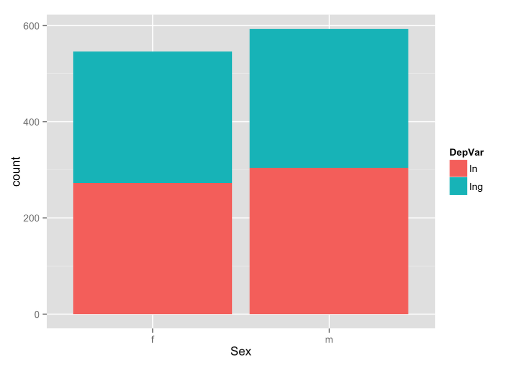

```r
ggplot(ing, aes(x = Sex, fill = DepVar)) +
  geom_bar()
```

This is a nice looking graph, but it’s not the most informative one we could make. We learn that we have more -ing words spoken by males, but it’s hard to compare the percent of each variant when we’re looking at stacked graphs like this.

A clearer graph would plot the proportion of IN by gender, and maybe even provide the total token count per bar. But we don’t have the proportion of IN by gender. No problem - we’ll just have to make it ourselves.

## “Split - Apply - Combine”

So let’s think about the task of calculating the proportion IN / (IN + ING) for each gender. We’ll do it the tedious way first, so that it’s most clear what the functions are doing - and then we’ll learn a sexy function family that makes our job **way** easier.

It’s pretty easy to create a column that is the proportion of IN / (IN + ING) in general. We just need to take the number of “In” and divide it by the total number of observations. There’s actually a few ways to get these numbers. I’ll walk through one way - if you can find your own, that’s great!

1. Find the proportion of “In” tokens, programmatically. We can use a logical operator to do this, `ing$DepVar == "In"`. This code will run the code iteratively over the vector ing$DepVar, and produce a vector of boolean values as the output. Here’s the great thing about boolean values: they are underlyingly 0’s and 1’s, where a 0 == FALSE and a 1 == TRUE. This means we can find the proportion of TRUE by asking for the mean value of that vector.

```r
head(ing$DepVar == "In")
```

```
## [1]  TRUE  TRUE FALSE  TRUE FALSE FALSE
```

```r
mean(ing$DepVar == "In")
```

```
## [1] 0.5065847
```

2. Assign that proportion to a new column:

```r
ing$prop <- mean(ing$DepVar == "In")
head(ing)
```

```
##       Token DepVar     Style  GramStatus Following.Seg Sex Age Ethnicity
## 54    going     In   careful progressive         vowel   f   2     Irish
## 55   giving     In   careful progressive         vowel   f   2     Irish
## 56 upcoming    Ing   careful   adjective         vowel   f   2     Irish
## 57    going     In   careful progressive         vowel   f   2     Irish
## 58 fighting    Ing   careful  participle        apical   f   2     Irish
## 59    going    Ing narrative progressive         vowel   f   2     Irish
##    Prop      prop
## 54  0.5 0.5065847
## 55  0.5 0.5065847
## 56  0.5 0.5065847
## 57  0.5 0.5065847
## 58  0.5 0.5065847
## 59  0.5 0.5065847
```

So great, we found the overall proportion of “In”. But to find something more informative, we want to find the proportion of “In” for each gender. We can do this by making two different subsets (one for male, one for female), applying the proportion formula over each one, and then combining them back together in a whole data frame.

```r
female <- subset(ing, Sex == "f")                        ## create a data frame of female speakers
female$Prop <- mean(female$DepVar == "In") ## find proportion of "In"
male <- subset(ing, Sex == "m")                           ## create a data frame of male speakers
male$Prop <- mean(male$DepVar == "In")       ## find proportion of "In"

ing <- rbind(female, male)            ## put them back togther by binding the rows with rbind()
head(ing)
```

```
##       Token DepVar     Style  GramStatus Following.Seg Sex Age Ethnicity
## 54    going     In   careful progressive         vowel   f   2     Irish
## 55   giving     In   careful progressive         vowel   f   2     Irish
## 56 upcoming    Ing   careful   adjective         vowel   f   2     Irish
## 57    going     In   careful progressive         vowel   f   2     Irish
## 58 fighting    Ing   careful  participle        apical   f   2     Irish
## 59    going    Ing narrative progressive         vowel   f   2     Irish
##    Prop      prop
## 54  0.5 0.5065847
## 55  0.5 0.5065847
## 56  0.5 0.5065847
## 57  0.5 0.5065847
## 58  0.5 0.5065847
## 59  0.5 0.5065847
```

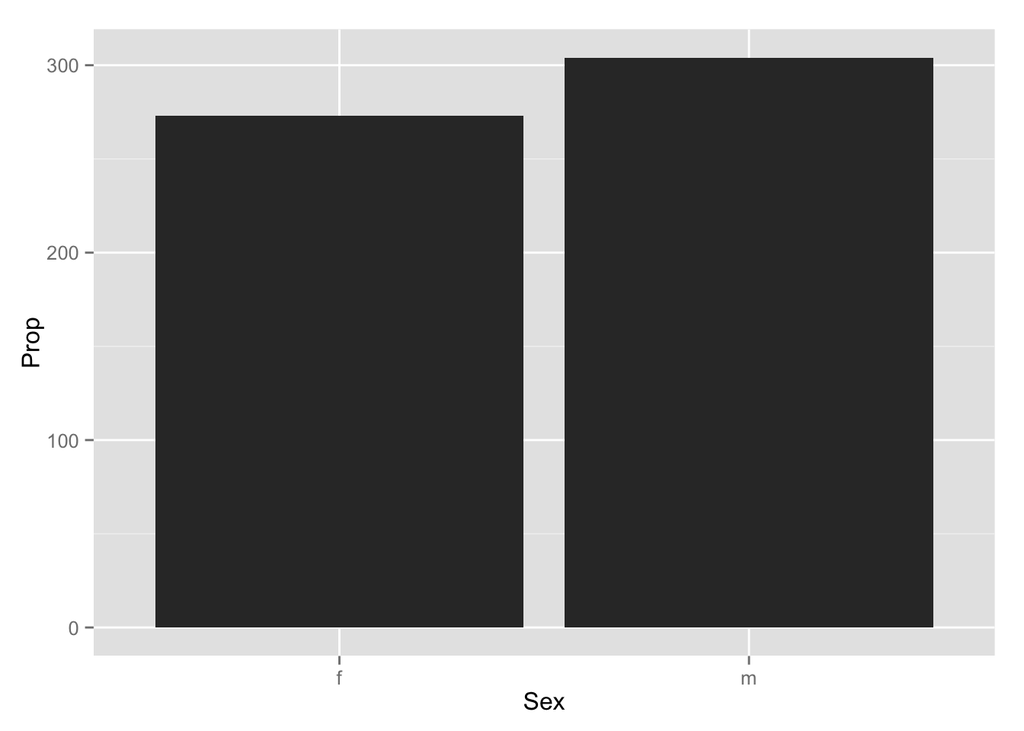

```r
ggplot(ing, aes(x = Sex, y = Prop)) +
  geom_bar(stat = "identity")
```

The hangup for `geom_bar()` is that it’s being asked to plot a single value multiple times. What we need is a small data frame that acts as a summary, instead of a column that repeats the summary multiple times. No problem - all we need to do is create a smaller data frame when we subset. We’ll use the function `data.frame()` to do this, which constructs a column for each argument you pass to it.

```r
female <- subset(ing, Sex == "f")  ## create a data frame of female speakers
f.prop <- mean(female$DepVar == "In") ## find proportion of "In", save it as a variable
f.sum <- data.frame(Gender = "f", Prop = f.prop) ## create summary data frame

male <- subset(ing, Sex == "m")    ## create a data frame of male speakers
m.prop <- mean(male$DepVar == "In") ## find proportion of "In"
m.sum <- data.frame(Gender = "m", Prop = m.prop) ## create summary data frame

## put the two summary dfs togther into one summary df by binding the rows with rbind()
sum.ing <- rbind(f.sum, m.sum)
head(sum.ing)
```

```
##   Gender      Prop
## 1      f 0.5000000
## 2      m 0.5126476
```

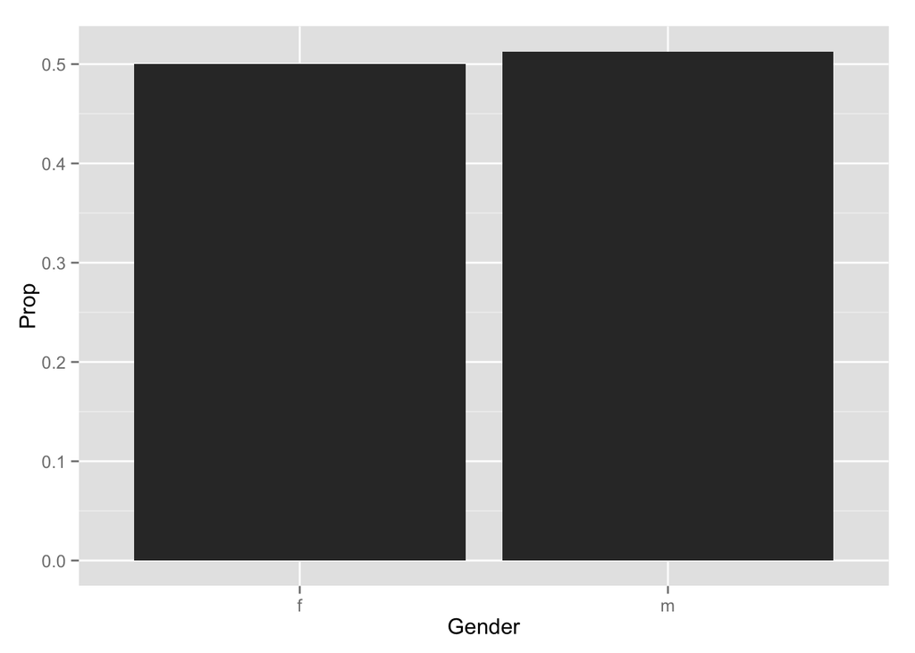

```r
ggplot(sum.ing, aes(x = Gender, y = Prop)) +
  geom_bar(stat="identity")
```

#### We did it!

Turns out, men and women in this data set use “In” at roughly the same proportion.

But this takes a lot of work, to split the data frames, apply a function, summarise the results, and combine them back together before we can plot informative graphs. Luckily, there’s a function family that exists to make this process easier and more intuitive. [`dplyr`](https://github.com/hadley/dplyr), by our pal Hadley Wickham.

## dplyr

I’m calling `dplyr` a family of functions, because it comprises a set of its own functions, and uses its own syntax to accomplish data manipulation goals. First let’s install and load `dplyr`.

```r
install.packages("dplyr")
library(dplyr)
```

### `%>%` operator

To begin with, we see that `dplyr` makes use of a new operator, `%>%`. This is called a forward pipe, or “pipe”, and it works by taking the object on the left and piping it through the function on the right. An easy way to see this in action is to try it out with my go-to function `head()`:

```r
ing %>% head()
```

```
##       Token DepVar     Style  GramStatus Following.Seg Sex Age Ethnicity
## 54    going     In   careful progressive         vowel   f   2     Irish
## 55   giving     In   careful progressive         vowel   f   2     Irish
## 56 upcoming    Ing   careful   adjective         vowel   f   2     Irish
## 57    going     In   careful progressive         vowel   f   2     Irish
## 58 fighting    Ing   careful  participle        apical   f   2     Irish
## 59    going    Ing narrative progressive         vowel   f   2     Irish
##    Prop      prop
## 54  0.5 0.5065847
## 55  0.5 0.5065847
## 56  0.5 0.5065847
## 57  0.5 0.5065847
## 58  0.5 0.5065847
## 59  0.5 0.5065847
```

The usefulness of `%>%` becomes more apparent when we’re dealing with data frame manipulation rather than base R functions. Let’s see what the `dplyr` code for summarising the proportion of “In” looks like.

```r
ing %>%
  group_by(Sex) %>%
  summarise(Prop = mean(DepVar == "In"))
```

```
## Source: local data frame [2 x 2]
##
##   Sex      Prop
## 1   f 0.5000000
## 2   m 0.5126476
```

Here, what we’ve done is: 1. Taken the `ing` data frame, and 2. Split it up by gender 3. Calculated the proportion of “In” tokens

`dplyr` automatically combines the results into a single data frame. We can assign this data frame to its own variable and plot it:

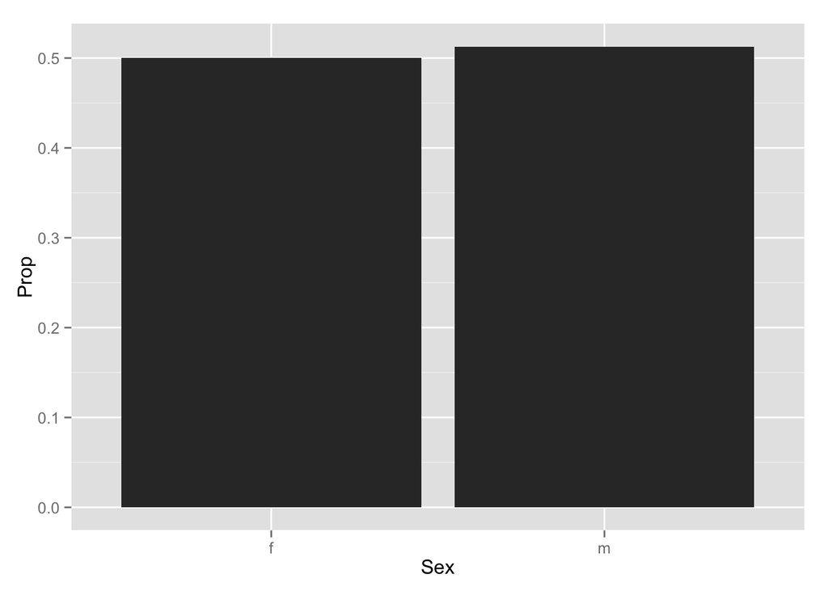

```r
new.ing <- ing %>%
  group_by(Sex) %>%
  summarise(Prop = mean(DepVar == "In"))

ggplot(new.ing, aes(x = Sex, y = Prop)) +
  geom_bar(stat = "identity")
```

At this point, I’m going to take a step back and provide a list of some of the basic functions in `dplyr`.

| Function | Does |
| --- | --- |
| `filter()` | Select just the rows you’re interested in |
| `group_by()` | Splits the data according to the arguments. If there are multiple arguments, it will split first by the first argument, then by the second. |
| `select()` | Select just the columns you’re interested in. |
| `mutate()` | Add new columns |
| `summarise()` | Summarise the data |

So the rates of “In” by gender aren’t very informative. But what about grammatical category? (Spoiler alert - we expect grammatical category to have a large effect on rates of “In”)!

Thanks to `dplyr`, it’s easy to ask any of these questions that we might have!

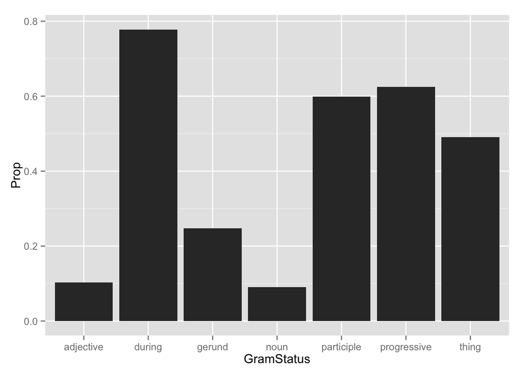

```r
gram_ing <- ing %>%
  group_by(GramStatus) %>%
  summarise(Prop = mean(DepVar == "In"))

ggplot(gram_ing, aes(x = GramStatus, y = Prop)) +
  geom_bar(stat = "identity")
```

What if men and women use different proportions for each category?

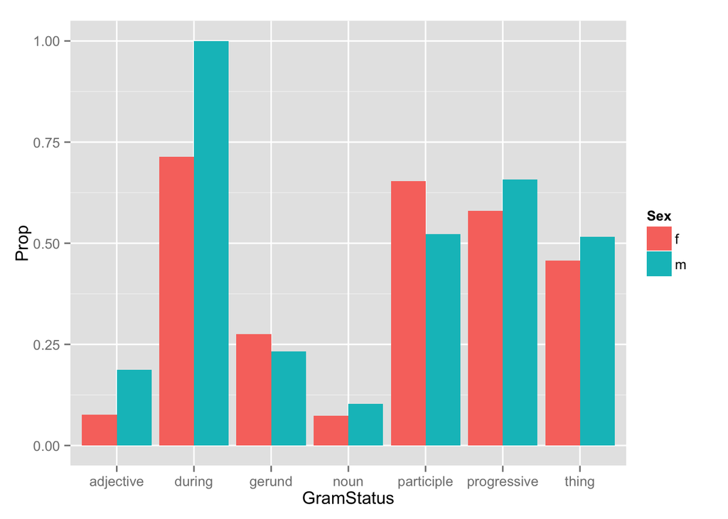

```r
gram_gend_ing <- ing %>%
  group_by(GramStatus, Sex) %>%
  summarise(Prop = mean(DepVar == "In"))

ggplot(gram_gend_ing, aes(x = GramStatus, y = Prop, fill = Sex)) +
  geom_bar(stat = "identity", position = "dodge")
```

#### Challenge: Create a plot to see whether style has an effect on the proportion of “In”. Do men and women behave differently in different speech styles?

#### Challenge: try to add error bars to the grammatical cateogry plot.

This is primarily a `dplyr` challenge, with elements of `ggplot` added in

[This](http://docs.ggplot2.org/0.9.3.1/geom_errorbar.html) documentation of geom_errorbar and [this](http://stackoverflow.com/questions/2676554/in-r-how-to-find-the-standard-error-of-the-mean) Stack Overflow question on calculating standard error will be helpful. Hint: answers with more upvotes are generally better.

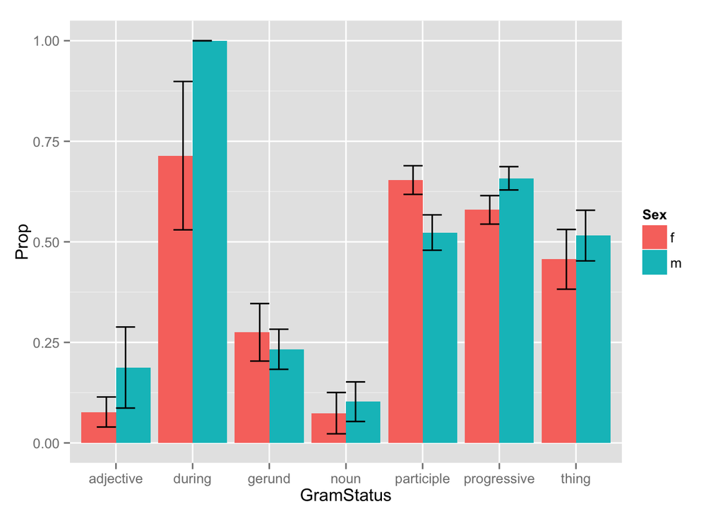

#### Challenge: Plot the rate of “In” over time (using Age as a proxy for DOB)

This is entirely a `ggplot` challenge.

Hint: First figure out how to plot a scatter plot of categorical data. Then add a statistics layer that will smooth between the categorical data.

```
## geom_smooth: method="auto" and size of largest group is <1000, so using loess. Use 'method = x' to change the smoothing method.
```

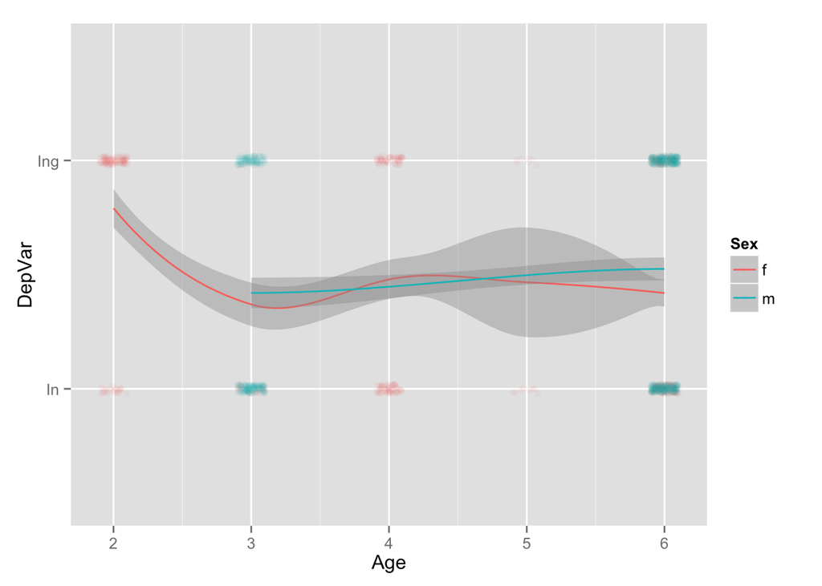